# 311 Calls

Daniel Kaplan

October 27, 2014

## Data Formats

It’s often surprisingly easy to access data tables in a variety of common formats. When it’s not easy, it can be very difficult indeed, requiring sophisticated programming skills and knowledge of data transmission formats, understanding of web-programming conventions, and so on.

These notes are not intended to show you how to solve the problems associated with difficult data formats. Instead, the point is to help you identify when acquiring data is going to be easy. When it is, you win. When it’s not, you likely want to enlist the help of an experienced programmer and data analyst.

### Computer Files

You may be aware that all computer files — text, images, sounds, data tables, etc. — are sequences of “binary digits,” generally called “bits.” In this sense, all computer files are the same. What’s different between different “types” of files is how the bits are intended to be interpreted: the format of the file.

Often, data tables are made available in one of several standard formats for computer files that are specifically designed for data tables. If the data you need are in one of these formats, you are likely to to have a pretty short path from the file you get to a data table that you can transfigure using the tools presented earlier.

Sometimes, the `.csv` files you want are already on the computer you are using for R (e.g., your own laptop). For files distributed over the Internet, the file location is usually specified by a complete URL, for instance:  
`http://www.mosaic-web.org/go/datasets/DCF/CountryCodes.csv`

When a file is on your own computer, you can use the `file.choose()` function to find the complete path name interactively. (But, because it’s interactive, don’t use `file.choose()` inside an RMD document.)

When a file is on the Internet, you can use a web browser to navigate to the site and then copy the URL for the file as a quoted character string in R.

#### CSV: Comma Separated Values

This is a simple format and widely used for data tables. All data analysis software — or even consumer or business software — that you are likely to use can read this format.

Generally, CSV files will be named with the suffix `.csv`.

Two good ways of reading `.csv` files to create a data table in R:

- `read.csv()` which takes as an argument the quoted character string giving the name of the file.
- `fread()` in the `data.table` package, which is used in the same way but more clever in dealing with a wider range of files. It’s also very fast, and so is the function to use when reading large files.

#### Example: 311 Calls

In New York City, dialing 311 connects you to a complaint/request service.[^1] New York provides information about individual calls to 311 on a [web site](https://data.cityofnewyork.us/Social-Services/311-Service-Requests-from-2010-to-Present/erm2-nwe9?).

I want to see how the number of 311 calls for different reasons varies over time of day and day of the week. I’m also interested in finding out whether there are hot spots for 311 calls, and how this depends on factors such as income.

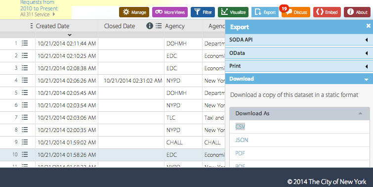

That site provides an “Export” feature. You can download the data in several formats: CSV is appropriate. The resulting file is slightly larger than 1GB. Using a web browser, I downloaded it to my `Downloads` directory.

##### What are the variables?

```r
CallsFile <- "~/Downloads/311_Service_Requests_from_2010_to_Present.csv"
CallsFile <- "~/Downloads/311-3-Cols.csv"
JustAPeek <-
  CallsFile %>%
  data.table::fread( nrows=2 )

names( JustAPeek )
```

```
[1] "Created Date"   "Complaint Type" "Incident Zip"
```

For my purposes, `CreatedDate`, `Complaint Type`, and `Incident Zip` are all I need. For other purposes, other variables might be important.

```r
# Not being evaluated
# SmallData <-
#   CallsFile %>%
#   fread( nrows=10, select=c(2,6,9))
```

Try more data, say, 10,000 calls, just to see if things work out:

```r
callsFile <- "~/Downloads/311-3-Cols.csv"
CallData <-
  fread( callsFile, nrows=10000,
         na.strings=c("NA","N/A",""),
         stringsAsFactors=FALSE ) %>%
  select( time=`Created Date`,
          complaint=`Complaint Type`,
          zip=`Incident Zip` ) %>%
  mutate( when=mdy_hms( time ))
```

### Develop your analysis using a small file

Pick a random subset of a few dozen cases. Develop your analysis on that. When something goes wrong, you may be able to figure it out by looking at the data tables to make sure they are what you expect them to be.

When you have something that works, you can increase the same to a few hundred, a few thousand, and so on. At each size, deal with the new problems that appear.

```r
testSize <- 500
```

```r
Small <-
  CallData %>%
  sample_n( size=testSize )
```

Take the most common forms of complaints. Graph the number of complaints per hour on each of the days of the week.

Convert the date-time to hour and day of the week:

```r
Small <- Small %>%
  mutate( hour=hour(when), day=wday(when) )
```

Pull out the five most common kinds of complaints.

1. Count the type of each kind of complaint, pick out the top five.

   ```r
   howManyTypes <- 5
   CommonComplaints <- Small %>%
   group_by( complaint ) %>%
     summarise( count=n() ) %>%
     filter( row_number( desc(count)) <= howManyTypes )
   ```

2. Pull out only those complaints that are among the common ones.

   ```r
   JustBigOnes <- Small %>%
     inner_join( CommonComplaints )
   ```

Find how many complaints of each major type there are in each hour.

```r
CountByHour <- JustBigOnes %>%
  group_by( complaint, hour ) %>%
  summarise( count=n() )
```

Plot out the number versus hour.

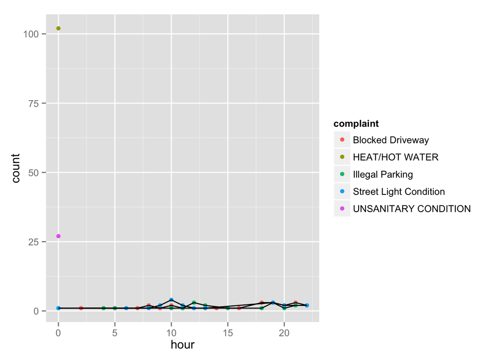

```r
ggplot( data=CountByHour,
          aes( x=hour, y=count )) +
  geom_point( aes(color=complaint) ) +
  geom_line( aes(group=complaint))
```

```r
testSize <- 1000
```

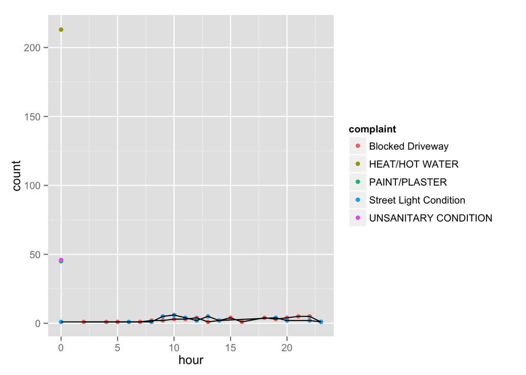

```r
JustBigOnes %>%
  filter( complaint=="HEAT/HOT WATER" ) %>%
  head()
```

```
                    time      complaint   zip       when
1 10/20/2014 12:00:00 AM HEAT/HOT WATER 10034 2014-10-20
2 10/20/2014 12:00:00 AM HEAT/HOT WATER 11374 2014-10-20
3 10/20/2014 12:00:00 AM HEAT/HOT WATER 10466 2014-10-20
4 10/20/2014 12:00:00 AM HEAT/HOT WATER 10458 2014-10-20
5 10/19/2014 12:00:00 AM HEAT/HOT WATER 11106 2014-10-19
6 10/20/2014 12:00:00 AM HEAT/HOT WATER 11226 2014-10-20
  hour day count
1    0   2   213
2    0   2   213
3    0   2   213
4    0   2   213
5    0   1   213
6    0   2   213
```

All of the suspect complaints are recorded exactly at midnight! Perhaps such complaints are entered in a different process, storing up all the complaints from the previous day. In any event, some cleaning is called for. Let’s delete all the complaints recorded at 12:00:00 AM.

```r
Small <- Small %>%
  filter( hour!=0, minute(when)!=0, second(when)!=0 )
```

[output not shown]

```r
testSize <- 50000
```

Try again …

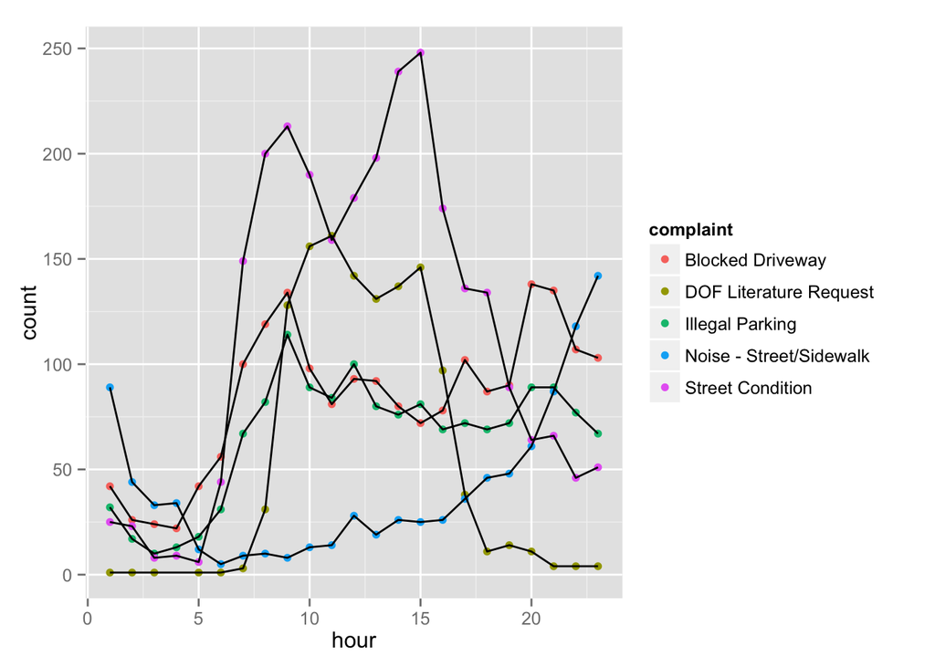

```r
testSize <- 50000
```

[figure not shown]

### For Instructors: Some tools for big files

`data.table::fread()` is much faster and other `data.table` functions?

`csvcut` from UNIX command line. Let’s you select variables and cleans up the CSV

```
csvcut -c 1,2,3,4,6,9,50,51 311Calls.csv > 311Simple.csv
```

[^1]: In the US, 911 is the phone number for emergency services. 311 is for non-emergency services.